# Analyse multidimensionnelle

Cheikh Talla

20/01/2022

## Analyse en composante principale

### Objectifs

Analyse en Composantes Principales (ACP) est une méthode statistique qui permet d’explorer des données dites multivariées (données avec plusieurs variables). Chaque variable pourrait être considérée comme une dimension différente.

L’analyse en composantes principales est utilisée pour extraire et de visualiser les informations importantes contenues dans une table de données multivariées. L’ACP synthétise cette information en seulement quelques nouvelles variables appelées composantes principales. Ces nouvelles variables correspondent à une combinaison linéaire des variables originels. Le nombre de composantes principales est inférieur ou égal au nombre de variables d’origine.

L’information contenue dans un jeu de données correspond à la variance ou l’inertie totale qu’il contient. L’objectif de l’ACP est d’identifier les directions (i.e., axes principaux ou composantes principales) le long desquelles la variation des données est maximale.

L’ACP réduit les dimensions d’une donnée multivariée à deux ou trois composantes principales, qui peuvent être visualisées graphiquement, en perdant le moins possible d’information.

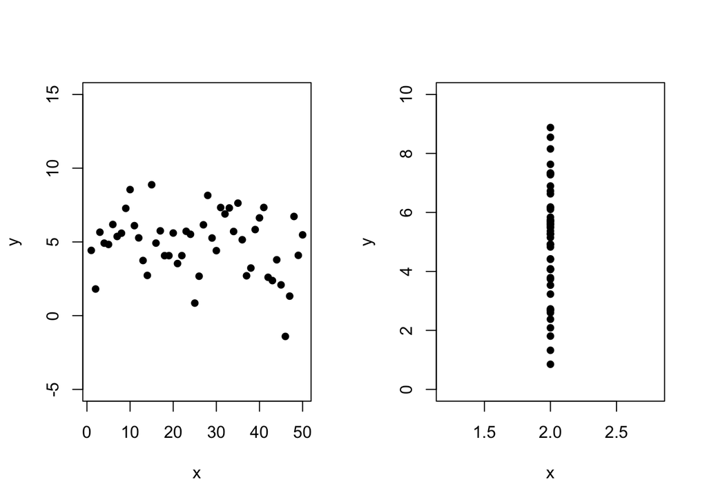

```r
par(mfrow=c(1,2))
x=1:50
y=rnorm(50, 5, 2)
plot(x,y, pch=16, ylim=c(-5,15))
x1 <- seq(0, 5,length.out = 50)
plot(rep(2, 50), y, ylim=c(0, 10), pch=16, xlab = "x")
```

Liste des packages utiles (“FactoMineR”, “factoextra”,“tidyverse”) install.packages(c(“FactoMineR”, “factoextra”))

## Package **FactoMiner**

Nous allons voir comment utiliser le package FactoMineR pour réaliser les calculs de l’ACP. Ce package est très complet et nous retourne tes les informations nécessaires.

### Données

Le jeu de données contient des statistiques sur les arrestations par 100 000 habitants pour assaut, meurtre et viol dans chacun des 50 États américains en 1973. On dispose donc d’une matrice de 50 lignes (les 50 états) et 4 colonnes

```r
library("FactoMineR")
library("factoextra")
data(USArrests)
head(USArrests)
```

```
           Murder Assault UrbanPop Rape
Alabama      13.2     236       58 21.2
Alaska       10.0     263       48 44.5
Arizona       8.1     294       80 31.0
Arkansas      8.8     190       50 19.5
California    9.0     276       91 40.6
Colorado      7.9     204       78 38.7
```

```r
colnames(USArrests)
```

```
[1] "Murder"   "Assault"  "UrbanPop" "Rape"
```

Nous povons éventuellement calculer la matrice de corrélation des variables initiales

```r
cor(USArrests)
```

```
             Murder   Assault   UrbanPop      Rape
Murder   1.00000000 0.8018733 0.06957262 0.5635788
Assault  0.80187331 1.0000000 0.25887170 0.6652412
UrbanPop 0.06957262 0.2588717 1.00000000 0.4113412
Rape     0.56357883 0.6652412 0.41134124 1.0000000
```

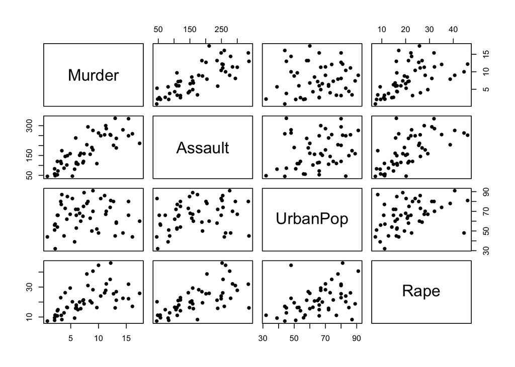

```r
pairs(USArrests, pch=16)
```

Identifier rapidement quelques paires de variables fortement corrélées, et quelques paires de variables quasiment décorrélées.

### Calcul de l’ACP

On utilise la fonction PCA(), dont voici les options principales

- scale.unit : travaille sur la matrice centrée par défaut (FALSE si on ne veut pas)
- ncp : nombre de composantes à retenir (5 par défaut)
- graph : affiche ou non les deux graphiques (oui par défaut)

```r
acp = PCA(USArrests, graph = FALSE)
```

L’objet renvoyé est une liste avec toutes les informations importantes (les sorties dela fonction).

```r
names(acp)
```

```
[1] "eig"  "var"  "ind"  "svd"  "call"
```

## Variance expliquée

Lobjet **eig** est une matrix, contenant pour chaque composante :

- les valeurs propres: (eigenvalues en anglais) mesurent la quantité de variance expliquée par chaque axe principal. Les valeurs propres sont grandes pour les premiers axes et petits pour les axes suivants. Autrement dit, les premiers axes correspondent aux directions portant la quantité maximale de variation contenue dans le jeu de données.
- le pourcentage de variance expliquée
- le pourcentage cumulé de variance expliquée

```r
acp$eig
```

```
       eigenvalue percentage of variance cumulative percentage of variance
comp 1  2.4802416              62.006039                          62.00604
comp 2  0.9897652              24.744129                          86.75017
comp 3  0.3565632               8.914080                          95.66425
comp 4  0.1734301               4.335752                         100.00000
```

La somme des valeurs propres est égale à 4

La proportion de variance expliquée par chaque valeur propre est donnée dans la deuxième colonne. Par exemple, 2.480 divisé par 4 est égal à 0.62, ou, environ 62% de la variation est expliquée par cette première valeur propre. Le pourcentage cumulé expliqué est obtenu en ajoutant les proportions successives de variances expliquées. Environ 86.74% de la variance totale est expliquée par les deux premières valeurs propres.

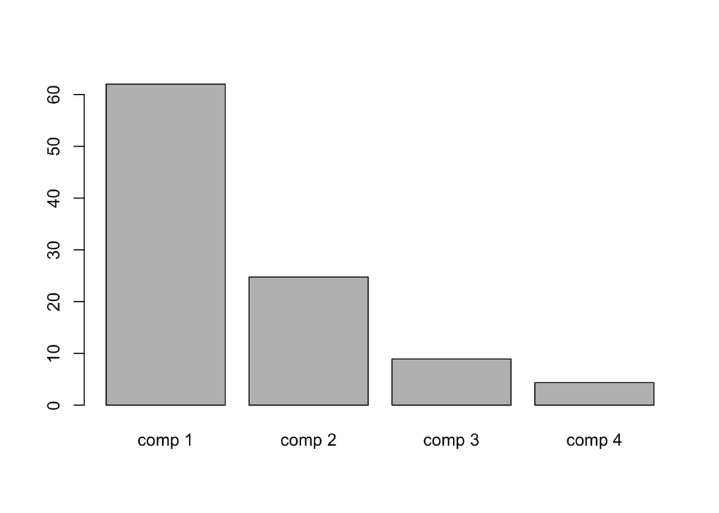

```r
barplot(acp$eig[,2],names.arg  = rownames(acp$eig))
```

Une valeur propre > 1 indique que la composante principale (PC) concernée représente plus de variance par rapport à une seule variable d’origine, lorsque les données sont standardisées. Ceci est généralement utilisé comme seuil à partir duquel les PC sont conservés. A noter que cela ne s’applique que lorsque les données sont normalisées.

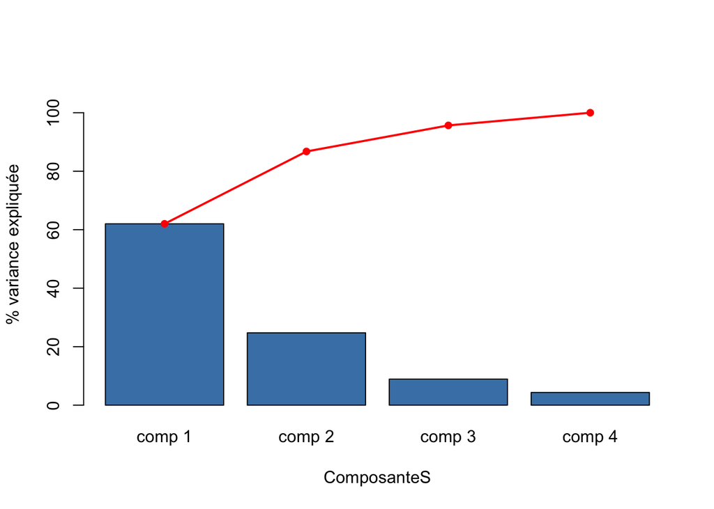

```r
xbar <- barplot(acp$eig[,2],names.arg  = rownames(acp$eig), ylim=c(0,110), ylab="% variance expliquée",xlab="ComposanteS",col ="steelblue")
lines(xbar,acp$eig[,3], pch=16, ylab="cumulative percentage of variance", type="o",col ="red", lwd=2)
```

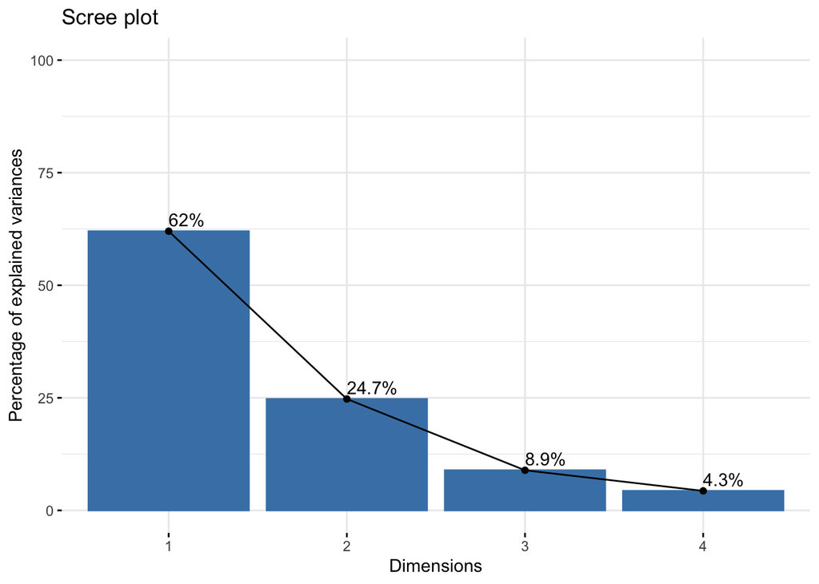

```r
library("factoextra")
fviz_eig(acp, addlabels = TRUE, ylim = c(0, 100))
```

### Résultats

Pour extraire les résultats, pour les variables, à partir de l’ACP est d’utiliser la fonction get_pca_var() [package factoextra]. Cette fonction retourne une liste d’éléments contenant tous les résultats pour les variables actives (coordonnées, corrélation entre variables et les axes, cosinus-carré et contributions)

```r
var <- get_pca_var(acp)
var
```

```
Principal Component Analysis Results for variables
 ===================================================
  Name       Description
1 "$coord"   "Coordinates for the variables"
2 "$cor"     "Correlations between variables and dimensions"
3 "$cos2"    "Cos2 for the variables"
4 "$contrib" "contributions of the variables"
```

Les composants de get_pca_var() peuvent être utilisés dans le graphique des variables comme suit:

- var$coord: coordonnées des variables pour créer un nuage de points.
- var$cos2: cosinus carré des variables. Représente la qualité de représentation des variables sur le graphique de l’ACP. Il est calculé comme étant les coordonnées au carré: var.cos2 = var.coord * var.coord.
- var$contrib: contient les contributions (en pourcentage), des variables, aux composantes principales. La contribution d’une variable (var) à une composante principale donnée: (var.cos2 * 100) / (total cos2 du composant).

### Cercle de corrélation

La corrélation entre une variable et une composante principale (PC) est utilisée comme coordonnées de la variable sur la composante principale. La représentation des variables diffère de celle des observations: les observations sont représentées par leurs projections, mais les variables sont représentées par leurs corrélations (Abdi and Williams 2010).

```r
# Coordonnées des variables
head(var$coord, 4)
```

```
             Dim.1      Dim.2      Dim.3       Dim.4
Murder   0.8439764 -0.4160354  0.2037600  0.27037052
Assault  0.9184432 -0.1870211  0.1601192 -0.30959159
UrbanPop 0.4381168  0.8683282  0.2257242  0.05575330
Rape     0.8558394  0.1664602 -0.4883190  0.03707412
```

#### Graphique des variables.

Les variables corrélées positivement sont du même côté du graphique. Les variables corrélées négativement sont sur des côtés opposés du graphique.

### Qualité de représentation

La qualité de représentation des variables sur la carte de l’ACP s’appelle cos2 (cosinus carré) .

```r
head(var$cos2)
```

```
             Dim.1     Dim.2      Dim.3       Dim.4
Murder   0.7122962 0.1730854 0.04151814 0.073100217
Assault  0.8435380 0.0349769 0.02563817 0.095846950
UrbanPop 0.1919463 0.7539938 0.05095143 0.003108430
Rape     0.7324611 0.0277090 0.23845544 0.001374491
```

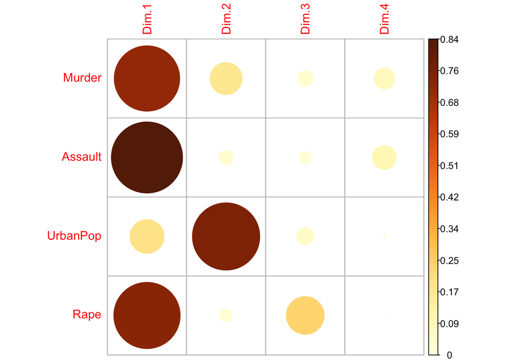

```r
library("corrplot")
corrplot(var$cos2, is.corr=FALSE)
```

- Un cos2 élevé indique une bonne représentation de la variable sur les axes principaux en considération. Dans ce cas, la variable est positionnée à proximité de la circonférence du cercle de corrélation.
- Un faible cos2 indique que la variable n’est pas parfaitement représentée par les axes principaux. Dans ce cas, la variable est proche du centre du cercle.

Pour une variable donnée, la somme des cos2 sur toutes les composantes principales est égale à 1. Si une variable est parfaitement représentée par seulement deux composantes principales (Dim.1 & Dim.2), la somme des cos2 sur ces deux axes est égale à 1. Dans ce cas, les variables seront positionnées sur le cercle de corrélation.

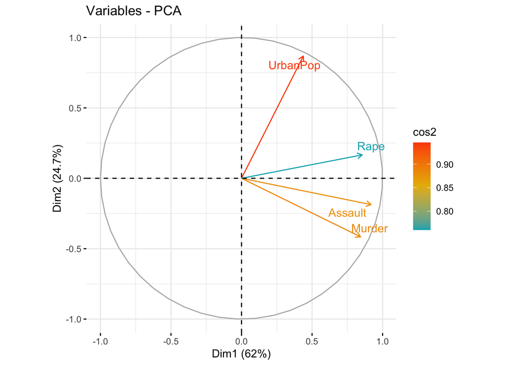

```r
# Colorer en fonction du cos2: qualité de représentation
fviz_pca_var(acp, col.var = "cos2",
             gradient.cols = c("#00AFBB", "#E7B800", "#FC4E07"),
             repel = TRUE # Évite le chevauchement de texte
             )
```

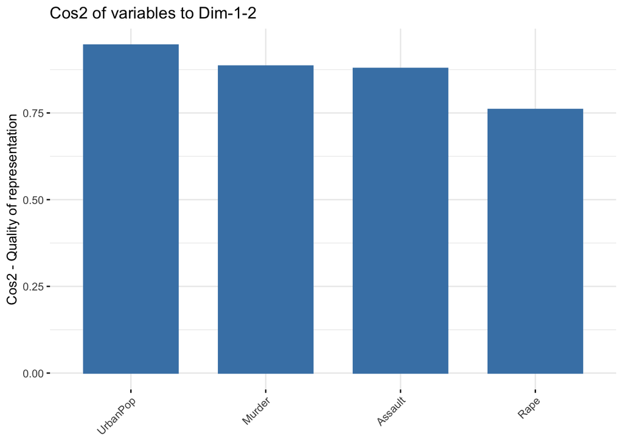

```r
# Cos2 total des variables sur Dim.1 et Dim.2
fviz_cos2(acp, choice = "var", axes = 1:2)
```

### Contributions des variables aux axes principaux

Les contributions des variables dans la définition d’un axe principal donné, sont exprimées en pourcentage.

Les variables corrélées avec PC1 (i.e., Dim.1) et PC2 (i.e., Dim.2) sont les plus importantes pour expliquer la variabilité dans le jeu de données. Les variables qui ne sont pas en corrélation avec un axe ou qui sont corrélées avec les derniers axes sont des variables à faible apport et peuvent être supprimées pour simplifier l’analyse globale.

```r
head(var$contrib)
```

```
             Dim.1     Dim.2     Dim.3     Dim.4
Murder   28.718825 17.487524 11.643977 42.149674
Assault  34.010315  3.533859  7.190358 55.265468
UrbanPop  7.739016 76.179065 14.289594  1.792325
Rape     29.531844  2.799553 66.876071  0.792533
```

Plus la valeur de la contribution est importante, plus la variable contribue à la composante principale en question.

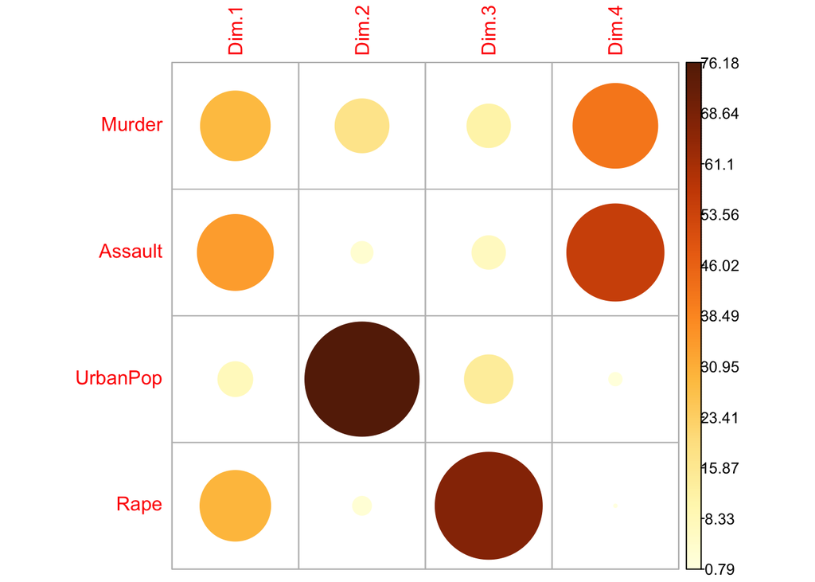

```r
library("corrplot")
corrplot(var$contrib, is.corr=FALSE)
```

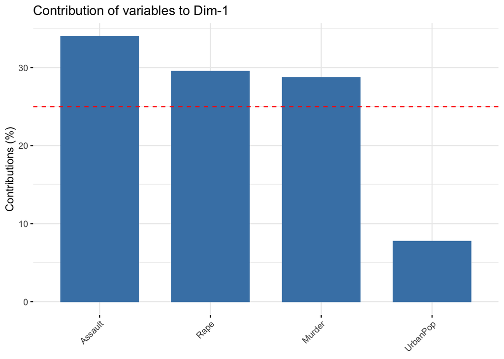

```r
# Contributions des variables à PC1
fviz_contrib(acp, choice = "var", axes = 1, top = 10)
```

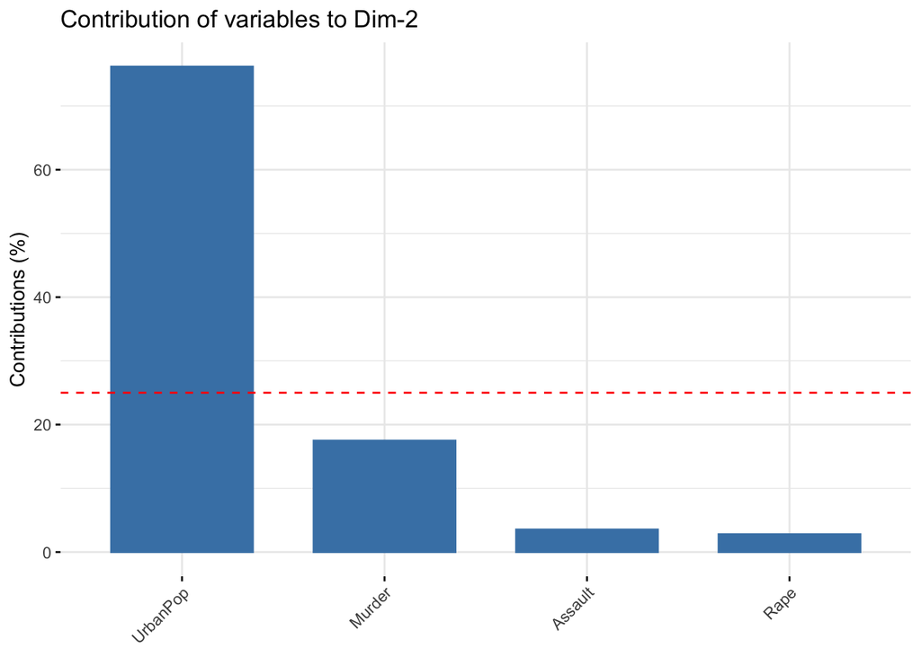

```r
# Contributions des variables à PC2
fviz_contrib(acp, choice = "var", axes = 2, top = 10)
```

La ligne en pointillé rouge, sur le graphique ci-dessus, indique la contribution moyenne attendue. Si la contribution des variables était uniforme, la valeur attendue serait 1/length(variables) = 1/4 = 25%. Pour une composante donnée, une variable avec une contribution supérieure à ce seuil pourrait être considérée comme importante pour contribuer à la composante.

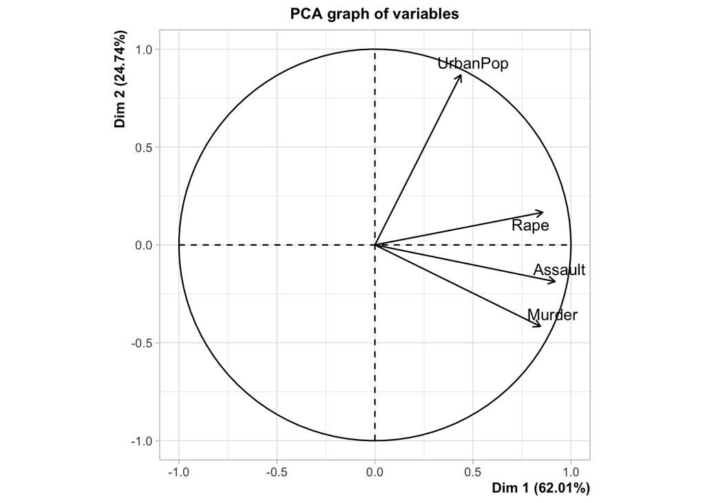

```r
plot(acp, choix = "var", autoLab = "yes")
```

### Graphique des individus

#### Résultats

Les résultats, pour les individus, peuvent être extraits à l’aide de la fonction get_pca_ind() [package factoextra]. Les individus similaires sont groupés ensemble.

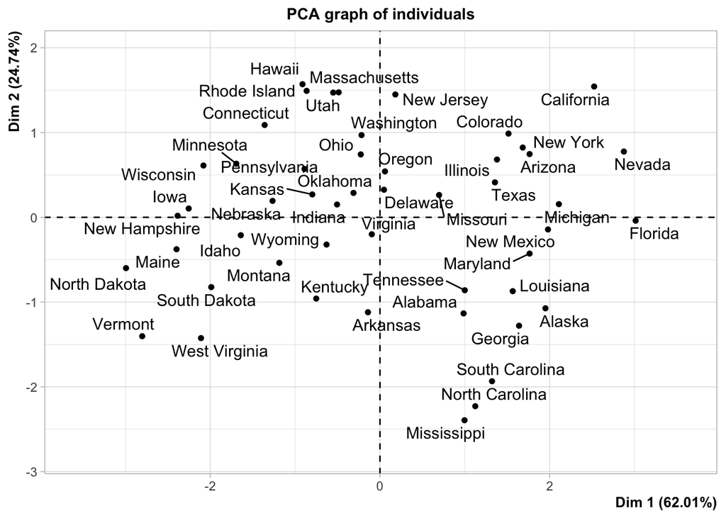

```r
plot(acp, choix = "ind", autoLab = "yes")
```

```r
ind <- get_pca_ind(acp)
ind
```

```
Principal Component Analysis Results for individuals
 ===================================================
  Name       Description
1 "$coord"   "Coordinates for the individuals"
2 "$cos2"    "Cos2 for the individuals"
3 "$contrib" "contributions of the individuals"
```

#### Graphique: qualité et contribution

La fonction fviz_pca_ind() est utilisée pour produire le graphique des individus

```r
# Coordonnées des individus
head(ind$coord)
```

```
                Dim.1      Dim.2       Dim.3        Dim.4
Alabama     0.9855659 -1.1333924  0.44426879  0.156267145
Alaska      1.9501378 -1.0732133 -2.04000333 -0.438583440
Arizona     1.7631635  0.7459568 -0.05478082 -0.834652924
Arkansas   -0.1414203 -1.1197968 -0.11457369 -0.182810896
California  2.5239801  1.5429340 -0.59855680 -0.341996478
Colorado    1.5145629  0.9875551 -1.09500699  0.001464887
```

```r
# Qualité des individus
head(ind$cos2)
```

```
                Dim.1     Dim.2        Dim.3        Dim.4
Alabama    0.39203099 0.5184533 0.0796600695 9.855631e-03
Alaska     0.40854247 0.1237310 0.4470626440 2.066384e-02
Arizona    0.71222383 0.1274849 0.0006875249 1.596038e-01
Arkansas   0.01514565 0.9496046 0.0099410946 2.530862e-02
California 0.69046522 0.2580267 0.0388311881 1.267690e-02
Colorado   0.51338268 0.2182676 0.2683492506 4.802583e-07
```

```r
# Contributions des individus
head(ind$contrib)
```

```
                Dim.1    Dim.2       Dim.3        Dim.4
Alabama    0.78326250 2.595723  1.10709555 0.2816053535
Alaska     3.06666679 2.327394 23.34292392 2.2182475522
Arizona    2.50680877 1.124411  0.01683258 8.0337329373
Arkansas   0.01612722 2.533823  0.07363144 0.3853982229
California 5.13697999 4.810526  2.00957508 1.3488039169
Colorado   1.84973970 1.970700  6.72554194 0.0000247465
```

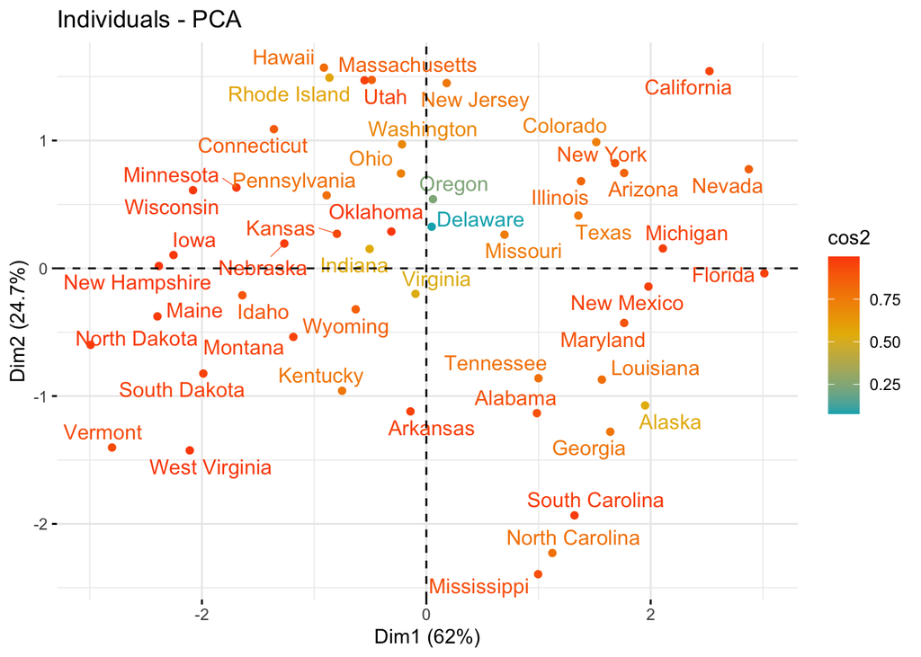

```r
fviz_pca_ind (acp, col.ind = "cos2",
             gradient.cols = c("#00AFBB", "#E7B800", "#FC4E07"),
             repel = TRUE # Évite le chevauchement de texte
             )
```

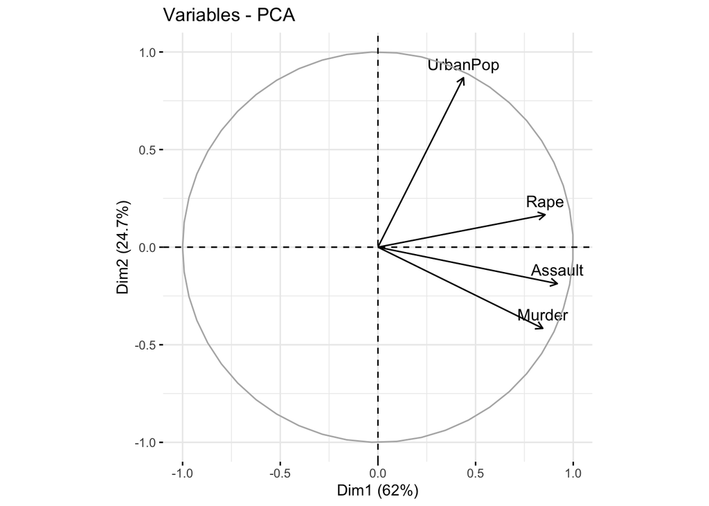

```r
fviz_pca_var(acp)
```

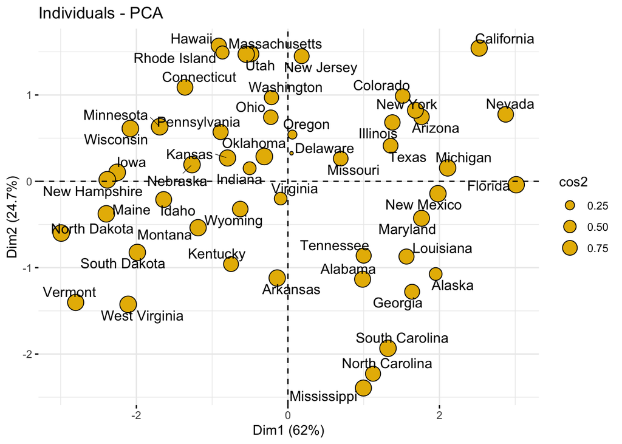

```r
fviz_pca_ind (acp, pointsize = "cos2",
             pointshape = 21, fill = "#E7B800",
             repel = TRUE # Évite le chevauchement de texte
             )
```

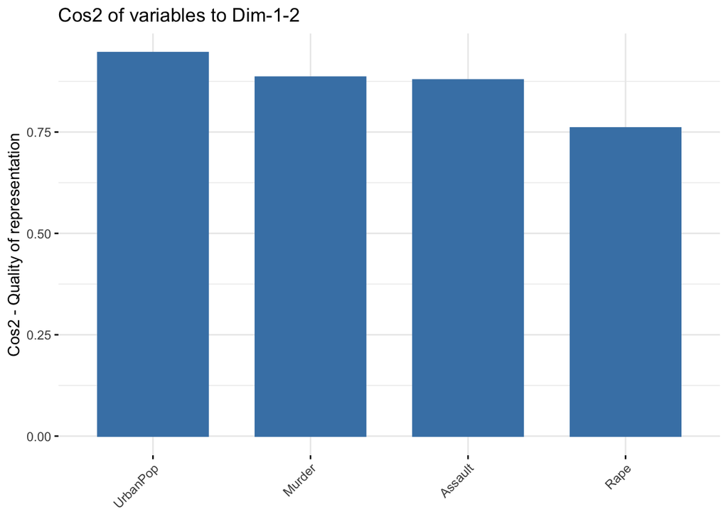

```r
fviz_cos2(acp, choice = "var", axes = 1:2)
```

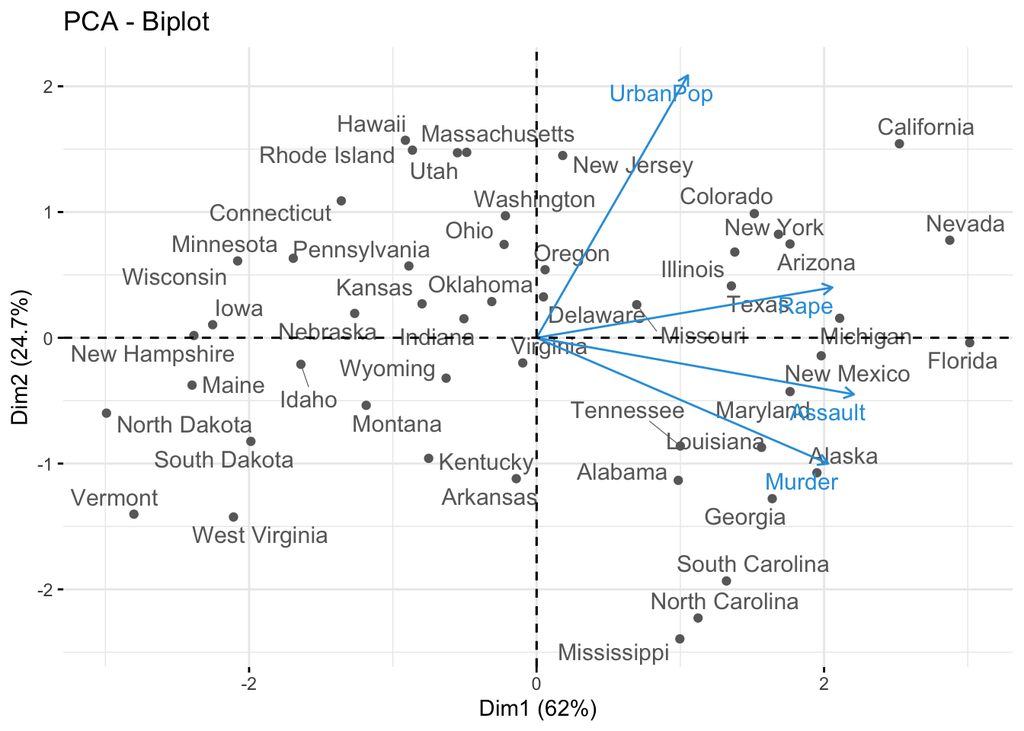

```r
fviz_pca_biplot(acp, repel = TRUE,
                col.var = "#2E9FDF", # Couleur des variables
                col.ind = "#696969"  # Couleur des individues
                )
```